# Avaliação Individual - Inferencia Estatística IV

FELIPE NERES SILVA BEZERRA

15 de julho de 2018

```
Não se esqueça de colocar o seu nome no cabeçalho desse arquivo. Esse arquivo pode ser enviado ao meu email até a próxima aula do próximo módulo.
Boa Prova!
```

## Objetivos

O seu papel nesta **avaliação** é avaliar e verificar os pressupostos dos modelos usando os seguintes processos no R

1. Construa os modelos lineares simples:
- Construa um modelo linear de $y$ em relação a $x$, usando a função `lm()`, com os objetos `y1`, `y2` e `y3` em relação ao objeto `x`. Atribua o resultado a um objeto chamado `modelo`.
2. Interprete o modelo construído.
- Veja o resumo do modelo usando a função `summary()` e interprete:
  - O intercepto é significativo (é diferente de zero)? Qual é o valor?
  - A inclinação tem um valor diferente de zero (é significativo)? Qual é o valor?
  - Qual é o ajuste do modelo ($R^2$)? Interprete.
3. Teste a normalidade dos resíduos com o teste de Shapiro-Wilk:
- Para isso utilize a função `shapiro.test()` no objeto originado da extração dos resíduos do modelo linear, usando a função `residuals()`: `shapiro.test(residuals(modelo))`;
- Interprete os resultados.
4. Verifique os pressupostos do modelo através de diagnóstico gráfico
- Peça ao R mudar o parâmetro de números de gráficos por área, para assim visualizar os 4 gráficos de diagnóstico do modelo ao mesmo tempo: `par(mfrow=c(2,2)`;
- Coloque os gráficos de diagnóstico usando a função `plot()`: `plot(modelo)`;
- Interprete os resultados.

## Carregamento dos dados

Os dados a seguir são artificiais e serão utilizados para serem construídos três modelos de Regressão Linear Simples:

1. `modelo_1`: `y1~x`
2. `modelo_2`: `y2~x`
3. `modelo_3`: `y3~x`

```r
x<-c(108.47,108.48,109.05,110.96,112.88,115.09,115.82,116.13,116.80,118.17,118.29,120.44,120.87,121.54,122.62,123.24,125.12,125.53,126.93,127.37,127.44,127.72,128.45,128.73,129.80,129.84,130.09,131.45,132.19,132.85,133.09,134.51,134.62,135.16,135.58,137.31,139.23,140.44,141.63,142.73,142.79,144.01,144.28,145.42,145.44,146.01,146.09,148.09,154.06,156.25)

y1 <- c(1926.3721,1845.5515,1836.9980,1814.8805,1818.7962,1804.6096,1799.2322,1831.1906,1785.4772,1816.7777,1724.7038,1672.9853,1686.6314,1757.8150,1657.6412,1564.5890,1598.9946,1723.5855,1542.1951,1598.8229,1559.7419,1571.9879,1526.9370,1404.5772,1483.3856,1585.6335,1441.7037,1609.2995,1533.9665,1365.9530,1517.2563,1236.0364,1496.6813,1362.1404,1440.2983,1309.6284,1249.1757,1255.1477,1183.9964,1171.6898,1203.4191,1146.1817,1187.4105,1030.8754,1077.6073,1125.5328,1091.1814,1013.9322,798.4727,759.3948)

y2 <- c(4253.423,4097.481,4242.749,4454.144,4435.041,4665.087,4462.745,4543.369,4344.700,4545.284,4514.208,4557.666,4683.720,4841.999,4814.493,4677.904,4703.944,4839.280,4658.370,4762.315,4863.913,5004.870,4789.697,4917.050,4960.285,4767.971,4887.572,4954.036,4916.751,5005.066,4943.923,5060.897,4951.924,4928.904,5290.459,4913.642,5108.266,5047.120,5202.368,5278.046,5149.564,5446.231,5386.824,5328.349,5193.366,5207.665,5474.012,5611.254,5469.710,5677.621)

y3 <- c(63.06316,61.44416,62.40146,62.46696,65.40710,73.91662,68.65933,79.84460,66.29297,68.79075,66.67182,72.32049,75.87358,70.13380,74.51058,69.67153,70.10120,80.35990,76.50786,72.05668,69.05673,75.02676,73.19806,75.10544,84.71027,74.82630,81.19418,72.50786,78.31355,77.92982,72.34656,80.75272,75.99446,77.68365,72.13723,72.79462,80.40959,81.88024,89.16389,80.91984,73.90764,80.15612,91.99874,76.81634,82.61463,84.67476,78.22375,82.27569,85.84750,87.58806)
```

## 1. Construção os modelos:

### A) Modelo y1 ~ x

Nesse primeiro já está pronto:

```r
modelo_1 <- lm(y1 ~ x)
```

### B) Modelo y2 ~ x

Complete a seguir:

```r
modelo_2 <- lm( y2 ~ x ) # Substitua os asteriscos **
```

### C) Modelo y3 ~ x

Faça você mesmo a construção do modelo com a função `lm()`:

```r
modelo_3 <- lm( y3 ~ x )# Coloque o comando aqui
```

## 2. Interpretação dos modelos construídos:

### A) Veja o resultado do `modelo_1`

A linha de comando já está feita a seguir:

```r
summary(modelo_1)
```

```
##
## Call:
## lm(formula = y1 ~ x)
##
## Residuals:
##      Min       1Q   Median       3Q      Max
## -135.231  -43.143   -0.619   33.884  167.560
##
## Coefficients:
##             Estimate Std. Error t value Pr(>|t|)
## (Intercept) 4469.061    111.526   40.07   <2e-16 ***
## x            -23.030      0.853  -27.00   <2e-16 ***
## ---
## Signif. codes:  0 '***' 0.001 '**' 0.01 '*' 0.05 '.' 0.1 ' ' 1
##
## Residual standard error: 73.02 on 48 degrees of freedom
## Multiple R-squared:  0.9382, Adjusted R-squared:  0.9369
## F-statistic: 728.9 on 1 and 48 DF,  p-value: < 2.2e-16
```

#### Qual o valor Intercepto? Ele é significativo? Interprete o resultado.

**R:** *O intercepto do Modelo 1 equivale a 4469,061 (valor de y1 para x=0). Uma vez que seu p-valor é consideravelmente menor que um alfa comumente atribuido como 0,05, corrobora para a hipótese alternativa de que o intercepto é significativamente diferente de zero.*

#### Qual é o valor do coeficiente angular? Ele é significativo? Interprete o resultado.

**R:** *O coeficiente angular do Modelo 1 equivale a -23,03; o sinal indica que há uma relação inversa entre a variável independente que correspode ao coeficiente e a variável dependente (y1 diminui conforme x aumenta). Uma vez que seu p-valor é consideravelmente menor que um alfa comumente atribuido como 0,05, corrobora para a hipótese alternativa de que este valor é significativamente diferente de zero.*

#### Qual é o valor do coeficiente de determinação ($R^2$) do modelo? Interprete o resultado.

**R:** *R quadrado do modelo corresponde a 0,9382; interpreta-se que 93,82% da relação entre y1 e x é explicada pelo modelo.*

### B) Veja o resultado do `modelo_2`

Complete a linha de comando a seguir:

```r
summary(modelo_2) # Substitua os asteriscos **
```

```
##
## Call:
## lm(formula = y2 ~ x)
##
## Residuals:
##     Min      1Q  Median      3Q     Max
## -185.53  -61.20  -14.87   59.07  240.43
##
## Coefficients:
##             Estimate Std. Error t value Pr(>|t|)
## (Intercept) 1198.995    165.861   7.229 3.28e-09 ***
## x             28.404      1.269  22.390  < 2e-16 ***
## ---
## Signif. codes:  0 '***' 0.001 '**' 0.01 '*' 0.05 '.' 0.1 ' ' 1
##
## Residual standard error: 108.6 on 48 degrees of freedom
## Multiple R-squared:  0.9126, Adjusted R-squared:  0.9108
## F-statistic: 501.3 on 1 and 48 DF,  p-value: < 2.2e-16
```

#### Qual o valor Intercepto? Ele é significativo? Interprete o resultado.

**R:** *O intercepto do Modelo 2 equivale a 1198,995 (valor de y2 para x=0). Uma vez que seu p-valor é consideravelmente menor que um alfa comumente atribuido como 0,05, corrobora para a hipótese alternativa de que o intercepto é significativamente diferente de zero.*

#### Qual é o valor do coeficiente angular? Ele é significativo? Interprete o resultado.

**R:** *O coeficiente angular do Modelo 2 equivale a 28,404; o sinal indica que há uma relação direta entre a variável independente que correspode ao coeficiente e a variável dependente (y2 aumenta conforme x aumenta). Uma vez que seu p-valor é consideravelmente menor que um alfa comumente atribuido como 0,05, corrobora para a hipótese alternativa de que este valor é significativamente diferente de zero.*

#### Qual é o valor do coeficiente de determinação ($R^2$) do modelo? Interprete o resultado.

**R:** *R quadrado do modelo corresponde a 0,9126; interpreta-se que 91,26% da relação entre y2 e x é explicada pelo modelo.*

### C) Veja o resultado do `modelo_3`

Faça você mesmo agora o comando necessário para ver o resultado do modelo:

```r
summary(modelo_3)# coloque o comando aqui
```

```
##
## Call:
## lm(formula = y3 ~ x)
##
## Residuals:
##     Min      1Q  Median      3Q     Max
## -7.3681 -2.9397 -0.5481  1.8503 10.9700
##
## Coefficients:
##             Estimate Std. Error t value Pr(>|t|)
## (Intercept) 14.85577    6.59208   2.254   0.0288 *
## x            0.46516    0.05042   9.226 3.31e-12 ***
## ---
## Signif. codes:  0 '***' 0.001 '**' 0.01 '*' 0.05 '.' 0.1 ' ' 1
##
## Residual standard error: 4.316 on 48 degrees of freedom
## Multiple R-squared:  0.6394, Adjusted R-squared:  0.6319
## F-statistic: 85.11 on 1 and 48 DF,  p-value: 3.31e-12
```

#### Qual o valor Intercepto? Ele é significativo? Interprete o resultado.

**R:** *O intercepto do Modelo 3 equivale a 14,85577 (valor de y3 para x=0). Uma vez que seu p-valor é razoavelmente menor que um alfa comumente atribuido como 0,05, corrobora para a hipótese alternativa de que o intercepto é significativamente diferente de zero.*

#### Qual é o valor do coeficiente angular? Ele é significativo? Interprete o resultado.

**R:** *O coeficiente angular do Modelo 3 equivale a 0,46516; o sinal indica que há uma relação direta entre a variável independente que correspode ao coeficiente e a variável dependente (y3 aumenta conforme x aumenta). Uma vez que seu p-valor é consideravelmente menor que um alfa comumente atribuido como 0,05, corrobora para a hipótese alternativa de que este valor é significativamente diferente de zero.*

## 3. Verifique a normalidade dos resíduos:

### A) Para o `modelo_1`

```r
shapiro.test(residuals(modelo_1))
```

```
##
##  Shapiro-Wilk normality test
##
## data:  residuals(modelo_1)
## W = 0.97158, p-value = 0.2681
```

##### Qual o resultado do teste? Interprete.

**R:** *Uma vez que seu p-valor é consideravelmente maior que um alfa comumente atribuido como 0,05, corrobora para a hipótese nula de que os resíduos do Modelo 1 seguem uma distribuição normal; em concordância com o pressuposto de normalidade dos resíduos exigido para regressões lineares.*

### B) Para o `modelo_2`

```r
shapiro.test(residuals(modelo_2)) # Subsitua os asteriscos **
```

```
##
##  Shapiro-Wilk normality test
##
## data:  residuals(modelo_2)
## W = 0.97398, p-value = 0.3335
```

##### Qual o resultado do teste? Interprete.

**R:** *Uma vez que seu p-valor é consideravelmente maior que um alfa comumente atribuido como 0,05, corrobora para a hipótese nula de que os resíduos do Modelo 2 seguem uma distribuição normal; em concordância com o pressuposto de normalidade dos resíduos exigido para regressões lineares.*

### C) Para o `modelo_3`

Escreva você mesmo todo o comando agora para executar um teste de Shapiro-Wilk com o terceiro modelo construído (`modelo_3`):

```r
shapiro.test(residuals(modelo_3)) # Coloque o comando aqui
```

```
##
##  Shapiro-Wilk normality test
##
## data:  residuals(modelo_3)
## W = 0.94293, p-value = 0.01761
```

##### Qual o resultado do teste? Interprete.

**R:** *Uma vez que seu p-valor é consideravelmente menor que um alfa comumente atribuido como 0,05, corrobora para a hipótese alternativa de que os resíduos do Modelo 3 não seguem uma distribuição normal; desrespeitando o pressuposto de normalidade dos resíduos exigido para regressões lineares. Recomenda-se que se utilize um método não-paramétrico.*

## 4. Verifique visualmente e faça o diagnóstico dos modelos:

### A) Para o `modelo_1`

O comando para fazer o diagnóstico gráfico do modelo já está escrito a seguir. Somente execute o comando e veja o resultado.

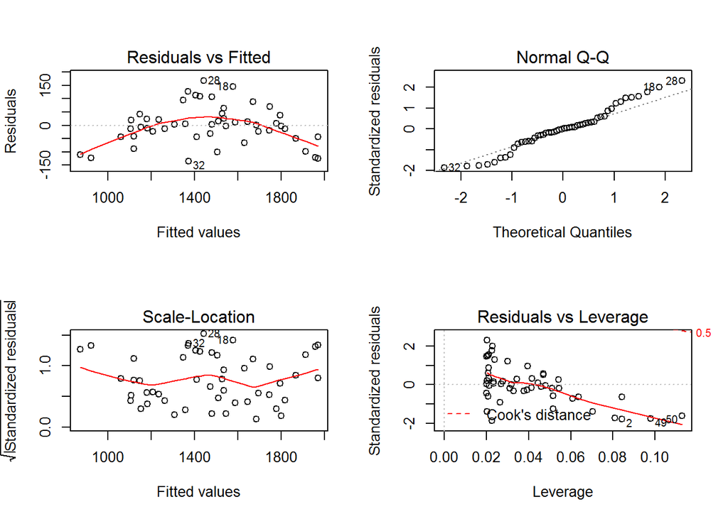

```r
par(mfrow=c(2,2))
plot(modelo_1)
```

### B) Para o `modelo_2`

Complete os comandos a seguir e veja o resultado.

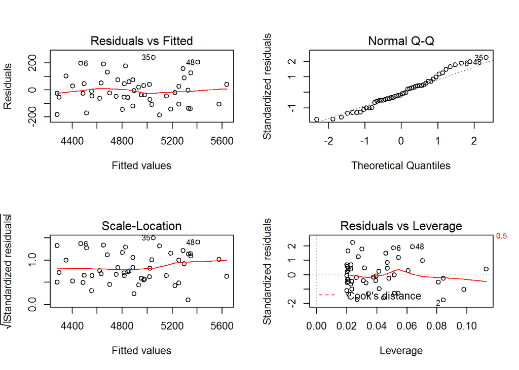

```r
par(mfrow=c(2,2)) # Subsitua os asteriscos **
plot(modelo_2)         # Subsitua os asteriscos **
```

### C) Para o `modelo_3`

Faça você mesmo agora todos os comandos necessários e faça o diagnóstico gráfico do modelo:

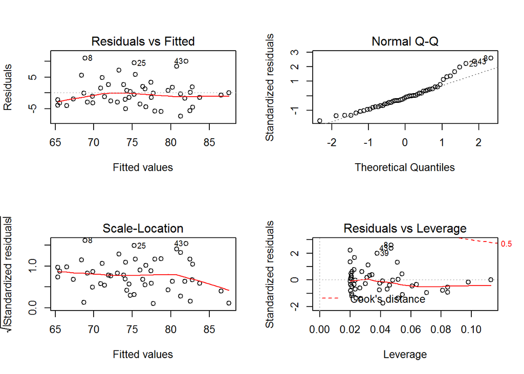

```r
par(mfrow=c(2,2))# Coloque o comando aqui
plot(modelo_3)# Coloque o comando aqui
```

## Conclusões

### Quais dos modelos seguem e quais modelos não seguem os pressupostos de uma regressão linear simples? Explique quais pressupostos não foram cumpridos e em quais modelos.

**R:** *Segundo análise gráfica, o Modelo 2 parece cumprir com os pressupostos de uma regressão linear simples; porém, o Modelo 1 não cumpre com o segue o pressuposto de linearidade e o Modelo 3 parece não cumprir com o pressuposto de normalidade dos resíduos.* *Nos modelos 2 e 3, a média dos resíduos permanece próxima de zero e a variância constante ao longo de todo o modelo (como observado nos gráficos “Resíduos vs Valores Ajustados” e “Scale-Location”). Já no modelo 1, a média dos resíduos não permanece próxima de zero ao longo de todo o modelo (a relação entre y1 e x não é linear).* *Nos modelos 1 e 2, observa-se um padrão linear ao relacionar os resíduos padronizados com quantis teóricos de uma distribuição normal (conforme o gráfico Normal Q-Q), indicando que os resíduos obedecem a uma distribuição normal. Algo que não pode ser observado no Modelo 3, que apresenta pontos discrepantes nos valores de resíduos mais altos.* *Alguns pontos em todos os três modelos podem ser apontados como possíveis outliers - a saber, as observações 2, 49 e 50 no Modelo 1; 2 e 48 no Modelo 2, e 8 e 43 no Modelo 3 - mesmo que pareçam não tão discrepantes dos demais ao serem observados no gráfico de Resíduos vs Alavancagem.*